# Home 5: Build a seq2seq model for machine translation.

### Name: Jeremiah McReynolds

### Task: Translate English to Russian

## 0. You will do the following:

1. Read and run my code.
2. Complete the code in Section 1.1 and Section 4.2.
   - Translation **English** to **German** is not acceptable!!! Try another pair of languages.
3. **Make improvements.** Directly modify the code in Section 3. Do at least one of the two. By doing both correctly, you will get up to 1 bonus score to the total.
   - Bi-LSTM instead of LSTM.
   - Attention. (You are allowed to use existing code.)
4. Evaluate the translation using the BLEU score.
   - Optional. Up to 1 bonus scores to the total.
5. Convert the notebook to .HTML file.
   - The HTML file must contain the code and the output after execution.
6. Put the .HTML file in your Google Drive, Dropbox, or Github repo. (If you submit the file to Google Drive or Dropbox, you must make the file "open-access". The delay caused by "deny of access" may result in late penalty.)
7. Submit the link to the HTML file to Canvas.

### Hint:

To implement `Bi-LSTM`, you will need the following code to build the encoder. Do NOT use Bi-LSTM for the decoder.

```
from keras.layers import Bidirectional, Concatenate

encoder_bilstm = Bidirectional(LSTM(latent_dim, return_state=True,
                                  dropout=0.5, name='encoder_lstm'))
_, forward_h, forward_c, backward_h, backward_c = encoder_bilstm(encoder_inputs)

state_h = Concatenate()([forward_h, backward_h])
state_c = Concatenate()([forward_c, backward_c])
```

## 1. Data preparation

1. Download data (e.g., "deu-eng.zip") from http://www.manythings.org/anki/
2. Unzip the .ZIP file.
3. Put the .TXT file (e.g., "deu.txt") in the directory "./Data/".

### 1.1. Load and clean text

```python
import re
import string
from unicodedata import normalize
import numpy

# load doc into memory
def load_doc(filename):
    # open the file as read only
    file = open(filename, mode='rt', encoding='utf-8')
    # read all text
    text = file.read()
    # close the file
    file.close()
    return text


# split a loaded document into sentences
def to_pairs(doc):
    lines = doc.strip().split('\n')
    pairs = [line.split('\t') for line in  lines]
    return pairs

def clean_data(lines):
    cleaned = list()
    # prepare regex for char filtering
    re_print = re.compile('[^%s]' % re.escape(string.printable))
    # prepare translation table for removing punctuation
    table = str.maketrans('', '', string.punctuation)
    for pair in lines:
        clean_pair = list()
        for line in pair:
            # normalize unicode characters
            line = normalize('NFD', line).encode('utf8')
            line = line.decode('utf8')
            # tokenize on white space
            line = line.split()
            # convert to lowercase
            line = [word.lower() for word in line]
            # remove punctuation from each token
            line = [word.translate(table) for word in line]
            # remove non-printable chars form each token
            # line = [re_print.sub('', w) for w in line]
            # remove tokens with numbers in them
            line = [word for word in line if word.isalpha()]
            # store as string
            clean_pair.append(' '.join(line))
        cleaned.append(clean_pair)
    return numpy.array(cleaned)
```

#### Fill the following blanks:

```python
# e.g., filename = 'Data/deu.txt'
filename = 'Data/rus.txt'

# e.g., n_train = 20000
n_train = 20000
```

```python
# load dataset
doc = load_doc(filename)

# split into Language1-Language2 pairs
pairs = to_pairs(doc)

# clean sentences
clean_pairs = clean_data(pairs)[0:n_train, :]
```

```python
for i in range(3000, 3010):
    print('[' + clean_pairs[i, 0] + '] => [' + clean_pairs[i, 1] + ']')
```

```
[tom danced] => [том станцевал]
[tom dances] => [том танцует]
[tom did it] => [том сделал это]
[tom did it] => [том это сделал]
[tom drinks] => [том]
[tom drives] => [том водит машину]
[tom failed] => [у тома ничего не вышло]
[tom failed] => [том потерпел фиаско]
[tom failed] => [том потерпел неудачу]
[tom failed] => [том не имел успеха]
```

```python
input_texts = clean_pairs[:, 0]
target_texts = ['\t' + text + '\n' for text in clean_pairs[:, 1]]

print('Length of input_texts:  ' + str(input_texts.shape))
print('Length of target_texts: ' + str(input_texts.shape))
```

```
Length of input_texts:  (20000,)
Length of target_texts: (20000,)
```

```python
max_encoder_seq_length = max(len(line) for line in input_texts)
max_decoder_seq_length = max(len(line) for line in target_texts)

print('max length of input  sentences: %d' % (max_encoder_seq_length))
print('max length of target sentences: %d' % (max_decoder_seq_length))
```

```
max length of input  sentences: 15
max length of target sentences: 45
```

**Remark:** To this end, you have two lists of sentences: input_texts and target_texts

## 2. Text processing

### 2.1. Convert texts to sequences

- Input: A list of $n$ sentences (with max length $t$).
- It is represented by a $n\times t$ matrix after the tokenization and zero-padding.

```python
from keras.preprocessing.text import Tokenizer
from keras.preprocessing.sequence import pad_sequences

# encode and pad sequences
def text2sequences(max_len, lines):
    tokenizer = Tokenizer(char_level=True, filters='')
    tokenizer.fit_on_texts(lines)
    seqs = tokenizer.texts_to_sequences(lines)
    seqs_pad = pad_sequences(seqs, maxlen=max_len, padding='post')
    return seqs_pad, tokenizer.word_index


encoder_input_seq, input_token_index = text2sequences(max_encoder_seq_length,
                                                      input_texts)
decoder_input_seq, target_token_index = text2sequences(max_decoder_seq_length,
                                                       target_texts)

print('shape of encoder_input_seq: ' + str(encoder_input_seq.shape))
print('shape of input_token_index: ' + str(len(input_token_index)))
print('shape of decoder_input_seq: ' + str(decoder_input_seq.shape))
print('shape of target_token_index: ' + str(len(target_token_index)))
```

```
shape of encoder_input_seq: (20000, 15)
shape of input_token_index: 27
shape of decoder_input_seq: (20000, 45)
shape of target_token_index: 44
```

```python
num_encoder_tokens = len(input_token_index) + 1
num_decoder_tokens = len(target_token_index) + 1

print('num_encoder_tokens: ' + str(num_encoder_tokens))
print('num_decoder_tokens: ' + str(num_decoder_tokens))
```

```
num_encoder_tokens: 28
num_decoder_tokens: 45
```

**Remark:** To this end, the input language and target language texts are converted to 2 matrices.

- Their number of rows are both n_train.
- Their number of columns are respective max_encoder_seq_length and max_decoder_seq_length.

The followings print a sentence and its representation as a sequence.

```python
target_texts[100]
```

```
'\tидите\n'
```

```python
decoder_input_seq[100, :]
```

```
array([ 3,  9, 19,  9,  5,  6,  4,  0,  0,  0,  0,  0,  0,  0,  0,  0,  0,
        0,  0,  0,  0,  0,  0,  0,  0,  0,  0,  0,  0,  0,  0,  0,  0,  0,
        0,  0,  0,  0,  0,  0,  0,  0,  0,  0,  0], dtype=int32)
```

## 2.2. One-hot encode

- Input: A list of $n$ sentences (with max length $t$).
- It is represented by a $n\times t$ matrix after the tokenization and zero-padding.
- It is represented by a $n\times t \times v$ tensor ($t$ is the number of unique chars) after the one-hot encoding.

```python
from keras.utils import to_categorical

# one hot encode target sequence
def onehot_encode(sequences, max_len, vocab_size):
    n = len(sequences)
    data = numpy.zeros((n, max_len, vocab_size))
    for i in range(n):
        data[i, :, :] = to_categorical(sequences[i], num_classes=vocab_size)
    return data

encoder_input_data = onehot_encode(encoder_input_seq, max_encoder_seq_length, num_encoder_tokens)
decoder_input_data = onehot_encode(decoder_input_seq, max_decoder_seq_length, num_decoder_tokens)

decoder_target_seq = numpy.zeros(decoder_input_seq.shape)
decoder_target_seq[:, 0:-1] = decoder_input_seq[:, 1:]
decoder_target_data = onehot_encode(decoder_target_seq,
                                    max_decoder_seq_length,
                                    num_decoder_tokens)

print(encoder_input_data.shape)
print(decoder_input_data.shape)
```

```
(20000, 15, 28)
(20000, 45, 45)
```

```python
input_texts[100], encoder_input_seq[100, :], encoder_input_data[100, :]
```

```
('go now',
 array([17,  4,  1,  8,  4, 16,  0,  0,  0,  0,  0,  0,  0,  0,  0],
       dtype=int32),
 array([[0., 0., 0., 0., 0., 0., 0., 0., 0., 0., 0., 0., 0., 0., 0., 0.,
         0., 1., 0., 0., 0., 0., 0., 0., 0., 0., 0., 0.],
        [0., 0., 0., 0., 1., 0., 0., 0., 0., 0., 0., 0., 0., 0., 0., 0.,
         0., 0., 0., 0., 0., 0., 0., 0., 0., 0., 0., 0.],
        [0., 1., 0., 0., 0., 0., 0., 0., 0., 0., 0., 0., 0., 0., 0., 0.,
         0., 0., 0., 0., 0., 0., 0., 0., 0., 0., 0., 0.],
        [0., 0., 0., 0., 0., 0., 0., 0., 1., 0., 0., 0., 0., 0., 0., 0.,
         0., 0., 0., 0., 0., 0., 0., 0., 0., 0., 0., 0.],
        [0., 0., 0., 0., 1., 0., 0., 0., 0., 0., 0., 0., 0., 0., 0., 0.,
         0., 0., 0., 0., 0., 0., 0., 0., 0., 0., 0., 0.],
        [0., 0., 0., 0., 0., 0., 0., 0., 0., 0., 0., 0., 0., 0., 0., 0.,
         1., 0., 0., 0., 0., 0., 0., 0., 0., 0., 0., 0.],
        [1., 0., 0., 0., 0., 0., 0., 0., 0., 0., 0., 0., 0., 0., 0., 0.,
         0., 0., 0., 0., 0., 0., 0., 0., 0., 0., 0., 0.],
        [1., 0., 0., 0., 0., 0., 0., 0., 0., 0., 0., 0., 0., 0., 0., 0.,
         0., 0., 0., 0., 0., 0., 0., 0., 0., 0., 0., 0.],
        [1., 0., 0., 0., 0., 0., 0., 0., 0., 0., 0., 0., 0., 0., 0., 0.,
         0., 0., 0., 0., 0., 0., 0., 0., 0., 0., 0., 0.],
        [1., 0., 0., 0., 0., 0., 0., 0., 0., 0., 0., 0., 0., 0., 0., 0.,
         0., 0., 0., 0., 0., 0., 0., 0., 0., 0., 0., 0.],
        [1., 0., 0., 0., 0., 0., 0., 0., 0., 0., 0., 0., 0., 0., 0., 0.,
         0., 0., 0., 0., 0., 0., 0., 0., 0., 0., 0., 0.],
        [1., 0., 0., 0., 0., 0., 0., 0., 0., 0., 0., 0., 0., 0., 0., 0.,
         0., 0., 0., 0., 0., 0., 0., 0., 0., 0., 0., 0.],
        [1., 0., 0., 0., 0., 0., 0., 0., 0., 0., 0., 0., 0., 0., 0., 0.,
         0., 0., 0., 0., 0., 0., 0., 0., 0., 0., 0., 0.],
        [1., 0., 0., 0., 0., 0., 0., 0., 0., 0., 0., 0., 0., 0., 0., 0.,
         0., 0., 0., 0., 0., 0., 0., 0., 0., 0., 0., 0.],
        [1., 0., 0., 0., 0., 0., 0., 0., 0., 0., 0., 0., 0., 0., 0., 0.,
         0., 0., 0., 0., 0., 0., 0., 0., 0., 0., 0., 0.]]))
```

## 3. Build the networks (for training)

- Build encoder, decoder, and connect the two modules to get "model".
- Fit the model on the bilingual data to train the parameters in the encoder and decoder.

### 3.1. Encoder network

- Input: one-hot encode of the input language
- Return:

  -- output (all the hidden states $h_1, \cdots , h_t$) are always discarded

  -- the final hidden state $h_t$

  -- the final conveyor belt $c_t$

```python
from keras.layers import Input, LSTM, Bidirectional, Concatenate
from keras.models import Model

latent_dim = 256

# inputs of the encoder network
encoder_inputs = Input(shape=(None, num_encoder_tokens),
                       name='encoder_inputs')

# set the LSTM layer
encoder_bilstm = Bidirectional(LSTM(latent_dim, return_state=True,
                    dropout=0.5, name='encoder_lstm'))
encoder_out, forward_h, forward_c, backward_h, backward_c = encoder_bilstm(encoder_inputs)

state_h = Concatenate()([forward_h, backward_h])
state_c = Concatenate()([forward_c, backward_c])

# build the encoder network model
encoder_model = Model(inputs=encoder_inputs,
                      outputs=[state_h, state_c],
                      name='encoder')
```

Print a summary and save the encoder network structure to "./encoder.pdf"

```python
from IPython.display import SVG
from keras.utils.vis_utils import model_to_dot, plot_model

SVG(model_to_dot(encoder_model, show_shapes=False).create(prog='dot', format='svg'))

plot_model(
    model=encoder_model, show_shapes=False,
    to_file='encoder.pdf'
)

encoder_model.summary()
```

```
Model: "encoder"
__________________________________________________________________________________________________
Layer (type)                    Output Shape         Param #     Connected to
==================================================================================================
encoder_inputs (InputLayer)     [(None, None, 28)]   0
__________________________________________________________________________________________________
bidirectional (Bidirectional)   [(None, 512), (None, 583680      encoder_inputs[0][0]
__________________________________________________________________________________________________
concatenate (Concatenate)       (None, 512)          0           bidirectional[0][1]
                                                                 bidirectional[0][3]
__________________________________________________________________________________________________
concatenate_1 (Concatenate)     (None, 512)          0           bidirectional[0][2]
                                                                 bidirectional[0][4]
==================================================================================================
Total params: 583,680
Trainable params: 583,680
Non-trainable params: 0
__________________________________________________________________________________________________
```

### 3.2. Decoder network

- Inputs:

  -- one-hot encode of the target language

  -- The initial hidden state $h_t$

  -- The initial conveyor belt $c_t$
- Return:

  -- output (all the hidden states) $h_1, \cdots , h_t$

  -- the final hidden state $h_t$ (discarded in the training and used in the prediction)

  -- the final conveyor belt $c_t$ (discarded in the training and used in the prediction)

```python
from keras.layers import Input, LSTM, Dense, Attention, TimeDistributed
from keras.models import Model

# inputs of the decoder network
decoder_input_h = Input(shape=(latent_dim * 2,), name='decoder_input_h')
decoder_input_c = Input(shape=(latent_dim * 2,), name='decoder_input_c')
decoder_input_x = Input(shape=(None, num_decoder_tokens), name='decoder_input_x')

# set the LSTM layer
decoder_lstm = LSTM(latent_dim * 2, return_sequences=True,
                    return_state=True, dropout=0.5, name='decoder_lstm')
decoder_lstm_outputs, state_h, state_c = decoder_lstm(decoder_input_x,
                                                      initial_state=[decoder_input_h, decoder_input_c])

# set the Attention layer
# attn_h, attn_c = Attention(name='attn_layer')([decoder_input_outputs, decoder_lstm_outputs])
# decoder_attn_out = Concatenate(axis=-1, name='attn_concat')([decoder_lstm_out, attn_h])

# set the Dense layer
decoder_dense = Dense(num_decoder_tokens, activation='softmax', name='decoder_dense')
decoder_outputs = decoder_dense(decoder_lstm_outputs)

# build the decoder network model
decoder_model = Model(inputs=[decoder_input_x, decoder_input_h, decoder_input_c],
                      outputs=[decoder_outputs, state_h, state_c],
                      name='decoder')
```

Print a summary and save the encoder network structure to "./decoder.pdf"

```python
from IPython.display import SVG
from keras.utils.vis_utils import model_to_dot, plot_model

SVG(model_to_dot(decoder_model, show_shapes=False).create(prog='dot', format='svg'))

plot_model(
    model=decoder_model, show_shapes=False,
    to_file='decoder.pdf'
)

decoder_model.summary()
```

```
Model: "decoder"
__________________________________________________________________________________________________
Layer (type)                    Output Shape         Param #     Connected to
==================================================================================================
decoder_input_x (InputLayer)    [(None, None, 45)]   0
__________________________________________________________________________________________________
decoder_input_h (InputLayer)    [(None, 512)]        0
__________________________________________________________________________________________________
decoder_input_c (InputLayer)    [(None, 512)]        0
__________________________________________________________________________________________________
decoder_lstm (LSTM)             [(None, None, 512),  1142784     decoder_input_x[0][0]
                                                                 decoder_input_h[0][0]
                                                                 decoder_input_c[0][0]
__________________________________________________________________________________________________
decoder_dense (Dense)           (None, None, 45)     23085       decoder_lstm[0][0]
==================================================================================================
Total params: 1,165,869
Trainable params: 1,165,869
Non-trainable params: 0
__________________________________________________________________________________________________
```

### 3.3. Connect the encoder and decoder

```python
# input layers
encoder_input_x = Input(shape=(None, num_encoder_tokens), name='encoder_input_x')
decoder_input_x = Input(shape=(None, num_decoder_tokens), name='decoder_input_x')

# connect encoder to decoder
encoder_final_states = encoder_model([encoder_input_x])
decoder_lstm_output, _, _ = decoder_lstm(decoder_input_x, initial_state=encoder_final_states)
decoder_pred = decoder_dense(decoder_lstm_output)

model = Model(inputs=[encoder_input_x, decoder_input_x],
              outputs=decoder_pred,
              name='model_training')
```

```python
from IPython.display import SVG
from keras.utils.vis_utils import model_to_dot, plot_model

SVG(model_to_dot(model, show_shapes=False).create(prog='dot', format='svg'))

plot_model(
    model=model, show_shapes=False,
    to_file='model_training.pdf'
)

model.summary()
```

```
Model: "model_training"
__________________________________________________________________________________________________
Layer (type)                    Output Shape         Param #     Connected to
==================================================================================================
encoder_input_x (InputLayer)    [(None, None, 28)]   0
__________________________________________________________________________________________________
decoder_input_x (InputLayer)    [(None, None, 45)]   0
__________________________________________________________________________________________________
encoder (Functional)            [(None, 512), (None, 583680      encoder_input_x[0][0]
__________________________________________________________________________________________________
decoder_lstm (LSTM)             [(None, None, 512),  1142784     decoder_input_x[0][0]
                                                                 encoder[0][0]
                                                                 encoder[0][1]
__________________________________________________________________________________________________
decoder_dense (Dense)           (None, None, 45)     23085       decoder_lstm[1][0]
==================================================================================================
Total params: 1,749,549
Trainable params: 1,749,549
Non-trainable params: 0
__________________________________________________________________________________________________
```

### 3.5. Fit the model on the bilingual dataset

- encoder_input_data: one-hot encode of the input language
- decoder_input_data: one-hot encode of the input language
- decoder_target_data: labels (left shift of decoder_input_data)
- tune the hyper-parameters
- stop when the validation loss stop decreasing.

```python
print('shape of encoder_input_data' + str(encoder_input_data.shape))
print('shape of decoder_input_data' + str(decoder_input_data.shape))
print('shape of decoder_target_data' + str(decoder_target_data.shape))
```

```
shape of encoder_input_data(20000, 15, 28)
shape of decoder_input_data(20000, 45, 45)
shape of decoder_target_data(20000, 45, 45)
```

```python
model.compile(optimizer='rmsprop', loss='categorical_crossentropy')

history = model.fit([encoder_input_data, decoder_input_data],  # training data
                     decoder_target_data,                       # labels (left shift of the target sequences)
                     batch_size=64, epochs=50, validation_split=0.2)

model.save('seq2seq.h5')
```

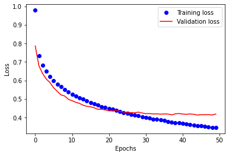

```python
import matplotlib.pyplot as plt
%matplotlib inline

acc = history.history['loss']
val_acc = history.history['val_loss']

epochs = range(len(acc))

plt.plot(epochs, acc, 'bo', label='Training loss')
plt.plot(epochs, val_acc, 'r', label='Validation loss')
plt.xlabel('Epochs')
plt.ylabel('Loss')
plt.legend()
plt.show()
```

## 4. Make predictions

### 4.1. Translate English to Russian

1. Encoder read a sentence (source language) and output its final states, $h_t$ and $c_t$.
2. Take the [star] sign "\t" and the final state $h_t$ and $c_t$ as input and run the decoder.
3. Get the new states and predicted probability distribution.
4. sample a char from the predicted probability distribution
5. take the sampled char and the new states as input and repeat the process (stop if reach the [stop] sign "\n").

```python
# Reverse-lookup token index to decode sequences back to something readable.
reverse_input_char_index = dict((i, char) for char, i in input_token_index.items())
reverse_target_char_index = dict((i, char) for char, i in target_token_index.items())
```

```python
def decode_sequence(input_seq, temperature: float):
    states_value = encoder_model.predict(input_seq)

    target_seq = numpy.zeros((1, 1, num_decoder_tokens))
    target_seq[0, 0, target_token_index['\t']] = 1.

    stop_condition = False
    decoded_sentence = ''
    while not stop_condition:
        output_tokens, h, c = decoder_model.predict([target_seq] + states_value)

        # this line of code is greedy selection
        # try to use multinomial sampling instead (with temperature)
        output_tokens = output_tokens[0, -1, :]
        output_tokens = output_tokens ** (1 / temperature)
        output_tokens = output_tokens / numpy.sum(output_tokens)  # Adding the multinomial adjustment
        sampled_token_index = numpy.argmax(output_tokens)

        # Sometimes the algorithm samples 0, which is an unknown token.
        # Resample to get the second highest prediction
        if sampled_token_index == 0:
            args = numpy.argsort(output_tokens)
            sampled_token_index = args[-2]

        sampled_char = reverse_target_char_index[sampled_token_index]
        decoded_sentence += sampled_char

        if (sampled_char == '\n' or
           len(decoded_sentence) > max_decoder_seq_length):
            stop_condition = True

        target_seq = numpy.zeros((1, 1, num_decoder_tokens))
        target_seq[0, 0, sampled_token_index] = 1.

        states_value = [h, c]

    return decoded_sentence
```

```python
for seq_index in range(2100, 2120):
    # Take one sequence (part of the training set)
    # for trying out decoding.
    input_seq = encoder_input_data[seq_index: seq_index+1]
    decoded_sentence = decode_sequence(input_seq, 0.2)
    print('-')
    print('English:       ', input_texts[seq_index])
    print('Russian (true): ', target_texts[seq_index][1:-1])
    print('Russian (pred): ', decoded_sentence[0:-1])
```

```
-
English:        follow him
Russian (true):  иди за ним
Russian (pred):  за ним
-
English:        follow him
Russian (true):  идите за ним
Russian (pred):  за ним
-
English:        follow him
Russian (true):  за ним
Russian (pred):  за ним
-
English:        forget tom
Russian (true):  забудь тома
Russian (pred):  забудьте тома
-
English:        forget tom
Russian (true):  забудьте тома
Russian (pred):  забудьте тома
-
English:        forget him
Russian (true):  забудь его
Russian (pred):  забудьте на тома
-
English:        forget him
Russian (true):  забудьте его
Russian (pred):  забудьте на тома
-
English:        forgive me
Russian (true):  простите меня
Russian (pred):  забудьте меня
-
English:        forgive me
Russian (true):  прости меня
Russian (pred):  забудьте меня
-
English:        forgive us
Russian (true):  прости нас
Russian (pred):  забудьте нас
```

[output cut: 25 more lines]

```
English:        get to bed
Russian (true):  марш в постель
Russian (pred):  пость е тома
-
English:        get to bed
Russian (true):  идите спать
Russian (pred):  пость е тома
-
English:        give it up
Russian (true):  попустись
Russian (pred):  возьми его
-
English:        go get tom
Russian (true):  сходи за томом
Russian (pred):  сходи за томом
```

### 4.2. Translate an English sentence to the target language

1. Tokenization
2. One-hot encode
3. Translate

```python
input_sentence = 'I love you'

input_sequence = pad_sequences([[input_token_index.get(char) for char in input_sentence.lower()]],
                               maxlen=max_encoder_seq_length,
                               padding='post')

input_x = onehot_encode(input_sequence, max_encoder_seq_length, 28)

translated_sentence = decode_sequence(input_x, 0.2)

print('source sentence is: ' + input_sentence)
print('translated sentence is: ' + translated_sentence)
```

```
source sentence is: I love you
translated sentence is: я люблю вас
```

## 5. Evaluate the translation using BLEU score

Reference:

- https://machinelearningmastery.com/calculate-bleu-score-for-text-python/
- https://en.wikipedia.org/wiki/BLEU

**Hint:**

- Randomly partition the dataset to training, validation, and test.
- Evaluate the BLEU score using the test set. Report the average.
- A reasonable BLEU score should be 0.1 ~ 0.5.

### Partition the Data

```python
all_pairs = clean_data(pairs)[:50000]
all_pairs.shape
```

```
(50000, 3)
```

```python
n, d = all_pairs.shape

train = int(n * .8)
val = int(n * .2)

indices = numpy.random.permutation(n)
train_indices = indices[:train-val]
val_indices = indices[train-val:train]
test_indices = indices[train:]

assert len(train_indices) + len(val_indices) + len(test_indices) == n
len(train_indices), len(val_indices), len(test_indices)
```

```
(30000, 10000, 10000)
```

```python
train_inputs = all_pairs[train_indices, 0]
train_outputs = [f'\t{text}\n' for text in all_pairs[train_indices, 1]]

val_inputs = all_pairs[val_indices, 0]
val_outputs = [f'\t{text}\n' for text in all_pairs[val_indices, 1]]

assert train_inputs[0] == all_pairs[train_indices[0], 0]
assert train_outputs[0] == f"\t{all_pairs[train_indices[0], 1]}\n"
train_inputs.shape, val_inputs.shape
```

```
((30000,), (10000,))
```

```python
train_inputs[100], train_outputs[100]
```

```
('does tom have it', '\tу тома это есть\n')
```

### Transform into Sequences

```python
max_encoder_seq_length = max(len(line) for line in train_inputs)
max_decoder_seq_length = max(len(line) for line in train_outputs)

print('max length of input  sentences: %d' % (max_encoder_seq_length))
print('max length of target sentences: %d' % (max_decoder_seq_length))
```

```
max length of input  sentences: 18
max length of target sentences: 60
```

```python
train_input_seq, input_token_index = text2sequences(max_encoder_seq_length,
                                                      train_inputs)
train_output_seq, target_token_index = text2sequences(max_decoder_seq_length,
                                                       train_outputs)

train_target_seq = numpy.zeros(train_output_seq.shape)
train_target_seq[:, 0:-1] = train_output_seq[:, 1:]

train_input_seq.shape, train_output_seq.shape, train_target_seq.shape
```

```
((30000, 18), (30000, 60), (30000, 60))
```

```python
val_input_seq = pad_sequences([[input_token_index[char] for char in sent] for sent in val_inputs],
                                maxlen=max_encoder_seq_length,
                                padding='post')
val_output_seq = pad_sequences([[target_token_index.get(char, 0) for char in sent] for sent in val_outputs],
                               maxlen=max_decoder_seq_length,
                               padding='post')

val_target_seq = numpy.zeros(val_output_seq.shape)
val_target_seq[:, 0:-1] = val_output_seq[:, 1:]

val_input_seq.shape, val_output_seq.shape, val_target_seq.shape
```

```
((10000, 18), (10000, 60), (10000, 60))
```

### One Hot Encode the Sequences

```python
num_encoder_tokens = len(input_token_index) + 1
num_decoder_tokens = len(target_token_index) + 1

num_encoder_tokens, num_decoder_tokens
```

```
(28, 43)
```

**Remark**: If you wanted to train all the data, you would need a generator. I tried it, but it's just too slow to train

```
def generator(x_train, y_train, encoder_length: int, encoder_tokens: int,
              decoder_length: int, decoder_tokens: int, batch_size: int = 32, epochs: int = 50) -> tuple:
    """ Generates batches of the x and y training data """
    encoder_data, decoder_data = x_train
    iters = int(encoder_data.shape[0] / batch_size)
    for i in range(epochs):
        start = 0
        for i in range(iters):
            end = start + batch_size

            encoder_batch = encoder_data[start:end]
            decoder_batch = decoder_data[start:end]
            decoder_target = y_train[start:end]

            encoder_train_data = onehot_encode(encoder_batch, encoder_length, encoder_tokens)
            decoder_train_data = onehot_encode(decoder_batch, decoder_length, decoder_tokens)
            decoder_target_data = onehot_encode(decoder_target, decoder_length, decoder_tokens)

            yield ([encoder_train_data, decoder_train_data], decoder_target_data)
            start = end
```

```
b = 32
train_epoch_steps = int(train_input_seq.shape[0] / b)
tr_generator = generator((train_input_seq, train_output_seq), train_target_seq,
                         encoder_length=max_encoder_seq_length, encoder_tokens=num_encoder_tokens,
                         decoder_length=max_decoder_seq_length, decoder_tokens=num_decoder_tokens)

val_epoch_steps = int(val_input_seq.shape[0] / b)
val_generator = generator((val_input_seq, val_output_seq), val_target_seq,
                          encoder_length=max_encoder_seq_length, encoder_tokens=num_encoder_tokens,
                          decoder_length=max_decoder_seq_length, decoder_tokens=num_decoder_tokens)
```

```python
encoder_train_data = onehot_encode(train_input_seq, max_encoder_seq_length, num_encoder_tokens)
decoder_train_data = onehot_encode(train_output_seq, max_decoder_seq_length, num_decoder_tokens)

train_target_seq = numpy.zeros(train_output_seq.shape)
train_target_seq[:, 0:-1] = train_output_seq[:, 1:]
decoder_train_target = onehot_encode(train_target_seq,
                                     max_decoder_seq_length,
                                     num_decoder_tokens)

encoder_train_data.shape, decoder_train_data.shape, decoder_train_target.shape
```

```
((30000, 18, 28), (30000, 60, 43), (30000, 60, 43))
```

```python
encoder_val_data = onehot_encode(val_input_seq, max_encoder_seq_length, num_encoder_tokens)
decoder_val_data = onehot_encode(val_output_seq, max_decoder_seq_length, num_decoder_tokens)

val_target_seq = numpy.zeros(val_output_seq.shape)
val_target_seq[:, 0:-1] = val_output_seq[:, 1:]
decoder_val_target = onehot_encode(val_target_seq,
                                    max_decoder_seq_length,
                                    num_decoder_tokens)

encoder_val_data.shape, decoder_val_target.shape, decoder_val_target.shape
```

```
((10000, 18, 28), (10000, 60, 43), (10000, 60, 43))
```

### Retrain the Model with the new Data

```python
from keras import backend as K

K.clear_session()
```

```python
latent_dim = 256

# inputs of the encoder network
encoder_inputs = Input(shape=(None, num_encoder_tokens),
                       name='encoder_inputs')

# set the LSTM layer
encoder_bilstm = Bidirectional(LSTM(latent_dim, return_state=True,
                    dropout=0.5, name='encoder_lstm'))
encoder_out, forward_h, forward_c, backward_h, backward_c = encoder_bilstm(encoder_inputs)

state_h = Concatenate()([forward_h, backward_h])
state_c = Concatenate()([forward_c, backward_c])

# build the encoder network model
encoder_model = Model(inputs=encoder_inputs,
                      outputs=[state_h, state_c],
                      name='encoder')
```

```python
# inputs of the decoder network
decoder_input_h = Input(shape=(latent_dim * 2,), name='decoder_input_h')
decoder_input_c = Input(shape=(latent_dim * 2,), name='decoder_input_c')
decoder_input_x = Input(shape=(None, num_decoder_tokens), name='decoder_input_x')

# set the LSTM layer
decoder_lstm = LSTM(latent_dim * 2, return_sequences=True,
                    return_state=True, dropout=0.5, name='decoder_lstm')
decoder_lstm_outputs, state_h, state_c = decoder_lstm(decoder_input_x,
                                                      initial_state=[decoder_input_h, decoder_input_c])

# set the Attention layer
# attn_h, attn_c = Attention(name='attn_layer')([decoder_input_outputs, decoder_lstm_outputs])
# decoder_attn_out = Concatenate(axis=-1, name='attn_concat')([decoder_lstm_out, attn_h])

# set the Dense layer
decoder_dense = Dense(num_decoder_tokens, activation='softmax', name='decoder_dense')
decoder_outputs = decoder_dense(decoder_lstm_outputs)

# build the decoder network model
decoder_model = Model(inputs=[decoder_input_x, decoder_input_h, decoder_input_c],
                      outputs=[decoder_outputs, state_h, state_c],
                      name='decoder')
```

```python
# input layers
encoder_input_x = Input(shape=(None, num_encoder_tokens), name='encoder_input_x')
decoder_input_x = Input(shape=(None, num_decoder_tokens), name='decoder_input_x')

# connect encoder to decoder
encoder_final_states = encoder_model([encoder_input_x])
decoder_lstm_output, _, _ = decoder_lstm(decoder_input_x, initial_state=encoder_final_states)
decoder_pred = decoder_dense(decoder_lstm_output)

model = Model(inputs=[encoder_input_x, decoder_input_x],
              outputs=decoder_pred,
              name='model_training')
```

```
model.compile(optimizer='rmsprop', loss='categorical_crossentropy')
history = model.fit(tr_generator, steps_per_epoch=train_epoch_steps, epochs=50,
                    validation_data=val_generator, validation_steps=val_epoch_steps)
```

```python
model.compile(optimizer='rmsprop', loss='categorical_crossentropy')

history = model.fit([encoder_train_data, decoder_train_data],  # training data
                     decoder_train_target,                       # labels (left shift of the target sequences)
                     batch_size=64, epochs=50,
                     validation_data=([encoder_val_data, decoder_val_data], decoder_val_target))
```

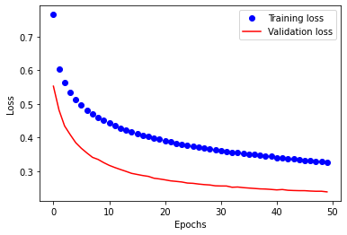

```python
loss = history.history['loss']
val_loss = history.history['val_loss']

epochs = range(len(loss))

plt.plot(epochs, loss, 'bo', label='Training loss')
plt.plot(epochs, val_loss, 'r', label='Validation loss')
plt.xlabel('Epochs')
plt.ylabel('Loss')
plt.legend()
plt.show()
```

```python
# Reverse-lookup token index to decode sequences back to something readable.
reverse_input_char_index = dict((i, char) for char, i in input_token_index.items())
reverse_target_char_index = dict((i, char) for char, i in target_token_index.items())
```

```python
for seq_index in range(2100, 2120):
    # Take one sequence (part of the training set)
    # for trying out decoding.
    text_index = train_indices[seq_index]
    input_seq = encoder_train_data[seq_index:seq_index+1]
    decoded_sentence = decode_sequence(input_seq, 0.2)
    print('-')
    print('English:       ', train_inputs[seq_index])
    print('Russian (true): ', train_outputs[seq_index][1:-1])
    print('Russian (pred): ', decoded_sentence[0:-1])
```

```
-
English:        youre forgiven
Russian (true):  вы прощены
Russian (pred):  ты нелорна
-
English:        are you her friend
Russian (true):  ты друг
Russian (pred):  ты довельно
-
English:        keep listening
Russian (true):  дальше
Russian (pred):  петь
-
English:        is everybody okay
Russian (true):  у всех в порядке
Russian (pred):  все в порядке
-
English:        youre cruel
Russian (true):  вы жестокая
Russian (pred):  ты просто
-
English:        who is tom to you
Russian (true):  том вам кем приходится
Russian (pred):  ком тебя том
-
English:        we walked slowly
Russian (true):  мы медленно шли
Russian (pred):  мы выглядим половым
-
English:        i made this chair
Russian (true):  я изготовил этот стул
Russian (pred):  я сделал этот стул
-
English:        i have an apple
Russian (true):  у меня есть яблоко
Russian (pred):  у меня есть сакар
-
English:        thats alright
Russian (true):  ладно
Russian (pred):  это просто
```

[output cut: 25 more lines]

```
English:        i didnt mean it
Russian (true):  я не нарочно
Russian (pred):  я этого не видел
-
English:        im not ashamed
Russian (true):  мне не стыдно
Russian (pred):  я не привер
-
English:        tom is holding it
Russian (true):  том его держит
Russian (pred):  том это пропит
-
English:        its too flashy
Russian (true):  он слишком бросается в глаза
Russian (pred):  оно слишком просто
```

### Evaluate the BLEU Score

- Get the test input data

```python
test_inputs = all_pairs[test_indices, 0]
test_inputs = numpy.unique(test_inputs)  # Get only the unique test inputs
test_inputs.shape
```

```
(8667,)
```

**Note:** Only need the test input sequence since we are using it to calculate the `BLEU` score.

```python
test_input_seq = pad_sequences([[input_token_index[char] for char in sent] for sent in test_inputs],
                                maxlen=max_encoder_seq_length,
                                padding='post')

test_input_seq.shape
```

```
(8667, 18)
```

```python
encoder_test_data = onehot_encode(test_input_seq, max_encoder_seq_length, num_encoder_tokens)
encoder_test_data.shape
```

```
(8667, 18, 28)
```

- Get all the references

```python
refs = dict()
for pair in all_pairs:
    eng, rus, desc = pair
    if not refs.get(eng):
        refs[eng] = list()
    refs[eng].append(rus.split())
refs['follow him']
```

```
[['за', 'ним'], ['иди', 'за', 'ним'], ['идите', 'за', 'ним'], ['за', 'ним']]
```

- Iterate through the samples, translate them, and then calculate the bleu score

```python
def decode(index: int, data: numpy.ndarray) -> list:
    """ Decodes the sequence of data """
    input_seq = data[index:index+1]
    pred = decode_sequence(input_seq, 0.2)[0:-1]
    return pred.split()
```

```python
from nltk.translate.bleu_score import sentence_bleu

bleu = list()
total = encoder_test_data.shape[0]
completed = 10
for seq_index in range(total):
    # Take one sequence (part of the training set)
    # for trying out decoding.
    source = test_inputs[seq_index]
    ref = refs[source]
    candidate = decode(seq_index, encoder_test_data)
    score = sentence_bleu(ref, candidate, (1,0,0,0))
    bleu.append(score)

    if seq_index != 0 and seq_index % (int(total * .1)) == 0:
        print(f"{completed}% completed")
        completed += 10

bleu[2000:2020]
```

```
10% completed
20% completed
30% completed
40% completed
50% completed
60% completed
70% completed
80% completed
90% completed
100% completed
```

```
[0.3032653298563167,
 0.25,
 0.25,
 0.5,
 0.3333333333333333,
 0.3333333333333333,
 0.5,
 0.5,
 0.5,
 0,
 0.25,
 1.0,
 0.75,
 0,
 0,
 0,
 0,
 0,
 1.0,
 0.75]
```

```python
sum(bleu) / len(bleu)
```

```
0.45834686464020596
```